# Transcriptome Analysis in Colorectal Cancer Diagnostics

Group 2: Joudy Raba Bakri Radwan Mouhaffel, Lea Skaar-Henriksen, Haldor Haugen, Gege Liu

2024-11-08

## Abstract

For classification of tumor and normal samples, we used two supervised machine learning algorithms, K-nearest neighbors (KNN) and random forest (RF), achieving 100% accuracy without any signs of overfitting and data leakage. Before building the model, the weights of the samples need to be calculated to address the imbalance of the number of instances between classes and used as parameters when fitting the dataset. The random forest model identified important genes that significantly contributed to the classification. GO enrichment analysis of these genes and DEGs highlighted key biological pathways and processes, such as cell signaling (particularly the Wnt pathway) and extracellular matrix organization, which are essential for tumorigenesis. These findings confirm the direction of our study and provide further biological insights into CRC.

## 1. Introduction

Colorectal cancer (CRC) is one of the most lethal cancers, which stresses the importance of new diagnostic approaches. For the BIN315 course project, our group selected the TCGA-COAD dataset which is a part of the Cancer Genome Atlas initiative that focuses on colorectal cancer. This was done to be able to utilize the knowledge gained in this class on differential gene expression analysis, machine learning and enrichment analysis to gain a better insight into this disease.

The TCGA-COAD dataset contains a large amount of RNA-Seq data which makes it possible to analyze gene expression in primary tumor and solid normal tissues in detail. RNA-Seq technology is very relevant for these studies since it enables the authors to determine which genes are differentially expressed and which pathways are affected during cancer progression, including the Wnt signaling pathway and the extracellular matrix remodeling. The results of these analyses are the presented with the goal of improving classification using Random Forests and K-Nearest Neighbor algorithm, as well as discovering new biomarkers with diagnostic value.

This paper presents an integrated pipeline approach for studying the mechanism of CRC. In this project, we not only aim to identify differentially expressed genes and stable biomarkers, but also employ machine learning models and performed functional enrichment analysis to provide research analysis. At the same time, this work presents the real-life use of various bioinformatics tools and techniques learned in this course.

### 1.1 Dataset

In this study, we utilized the TCGA-COAD dataset, which is publicly available through the Cancer Genome Atlas (TCGA) research network at https://portal.gdc.cancer.gov/, and contains multi-omics data. We specifically focused on RNA-Seq data, accessed via the TCGAbiolinks R package[1]. This dataset includes a key attribute, sample_type, which allows us to distinguish between primary tumor samples and solid tissue normal samples, making it well-suited for classification analysis.

## 2. Methods

### 2.1 Libraries

The libraries used in our analysis are listed below.

```r
suppressMessages({
library(TCGAbiolinks)
library(SummarizedExperiment)
library(edgeR)
library(DESeq2)
library(tidyverse)
library(matrixStats)
library(clusterProfiler)
library(org.Hs.eg.db)
library(dplyr)
library(caret)
library(class)
library(smotefamily)
library(randomForest)
})
```

### 2.2 Principal Component Analysis

PCA is an unsupervised dimensionality reduction method that transforms the original feature set into a set of linearly independent variables. This transformation can help us not only maintain most of the original information when selecting several principle components, but also improve computational efficiency and dataset visualization and feature selection [3]. Here, we performed principal component analysis by the prcomp() function to better understand our dataset and choose the number of principal components for dimensionality reduction.

### 2.3 Differential Expression Analysis

The purpose of differential expression analysis in this study is to find out the genes whose expression data are upregulated or downregulated in normal samples and cancer samples through statistical tests. This approach helps to provide important insights for cancer research and find the potential biomarkers and mechanisms associated with tumor progression and recurrence [4].

Here, we utilized the DESeq2 package, which is widely-used tool for differential genes analysis of RNA-seq data. DESeq2 package apply the negative binomial models to fit the count-based RNA-Seq data which is different from Limma package that uses linear linear models for the microarray data, as the RNA-Seq data has discrete and over-dispersed characteristics. The key steps in DESeq2 differential expression analysis include data normalization, fitting a negative binomial distribution, estimating dispersion, performing differential expression testing, and correcting for multiple hypothesis testing. Then, the threshold needs to be carefully selected when identifying DEGs (Differentially Expressed Genes), which is an important step to ensure the reliability and accuracy of the analysis results. The choice of measuring statistical significance, such as p-value, p-value adjusted by different techniques (padj), and the size of the difference (expressed as log2 fold change (l2FC)), is crucial because it actually directly affects the reliability of the results and the interpretation of the data [4].

### 2.4 Supervised Methods

#### 2.4.1 Class Balance

Class balance is a method to combat data imbalance when analysing data. This imbalance occurs as a consequence of the difference in availability of tissue samples. The chosen dataset exhibits a significant class imbalance, with far more Tumor samples (378) than Normal samples (41). Addressing this imbalance is crucial to ensure unbiased model performance and reliable predictions. Common approaches to tackle imbalance include undersampling the majority class, oversampling the minority class, generating synthetic samples or applying class weights.

The chosen method for class balance in this study was weighting, in order to address the imbalance. This method adjusts for class frequency by assigning weights inversely proportional to class size, ensuring that both classes are fairly represented during modeling. The benefits of weighting is that it retains all original data, preserving its integrity, and avoids the computational overhead of generating synthetic samples with other methods like SMOTE. Additionally, it is particularly effective for high-dimensional data, where oversampling methods may struggle with the curse of dimentionality. Also it is more efficient and requires less computational power.

#### 2.4.2 Random forest(RF)

Random Forest modelling is well-suited for high-dimensional data, performing effectively with a large number of features without the need for explicit dimentionality reduction. It is robust to overfitting due to its ensemble approach, which combines multiple decision trees to improve generalization and reduce variance. Additionally, Random Forest naturally handles class imbalance by allowing the adjustment of class weights (classwt), ensuring fair representation of minority classes during model training.

#### 2.4.3 K-nearest neighbour(KNN)

K-nearest neighbour is another supervised method that looks at similar samples in feature space to determine what class the observation belongs in. Unlike random forest this method is prone to overfitting, and not very well suited for high-dimentional data, which in turn means dimentionality reduction like PCA is preferable for the method to provide useful data. K-nearest neighbour also struggles with imbalanced data, which is the reason weighted kNN is being utilized in this study.

#### 2.4.4 Evaluation

Model evaluation is a method of ensuring accurate and reliable performance of models utilized in data analysis. The different methods used in this study are accuracy and error rate, confusion matrix and cross-validation. Accuracy is used to measure samples correctly classified, and error rate is used to determine incorrect predictions. Together they reflect the effectiveness of the model. Confusion matrix provides a breakdown of how well a model, like RF, performs for each class. Lastly, cross-validation is used to ensure the model performs well on unseen data, by attempting to detect potential overfitting. It does this by training on one part of the data, and testing on another unseen part of the data to make sure the model doesn’t pick up noise from the training data that won’t translate to the test data.

### 2.5 Go Enrichment analysis

Gene Ontology (GO) enrichment analysis is a method used to highlight key biological processes associated with genes that distinguished tumor and normal samples. After differential expression analysis, significantly up-and down-regulated genes, aswell as genes detected through RF, can be further analysed to gain insight into the function of the genes by linking these genes to relevant biological processes. This analysis allows for the identification of key mechanisms and pathways related to colorectal cancer.

## 3. Results

The Results section contains the analysis and results of a series of processes including preprocessing, PCA, differential analysis, and modeling using machine learning algorithms.

### 3.1 Exploring and preprocessing

#### 3.1.1 Exploring

This dataset contains gene expression data of various samples. It consists of 522 columns (each column represents a different sample) and 60,660 rows (each row corresponds to a gene transcript).

```r
data_filtered <- readRDS("data_filtered.rds")
sample_types_filtered <- readRDS("sample_types_filtered.rds")
data.counts <- data.frame(data_filtered)
dim(data.counts)
```

```
## [1] 60660   522
```

```r
data.counts[1:5,1:2]
```

```
##                    TCGA.AA.3692.01A.01R.0905.07 TCGA.AA.3662.11A.01R.1723.07
## ENSG00000000003.15                         8872                         7576
## ENSG00000000005.6                             7                           33
## ENSG00000000419.13                         1497                         1238
## ENSG00000000457.14                          504                          869
## ENSG00000000460.17                          378                          132
```

Then, a sample type distribution plot was drawn, with 481 “primary tumor” type samples and 41 “solid tissue normal” type samples. It can be seen that the number of tumor samples is higher than that of normal tissue samples.

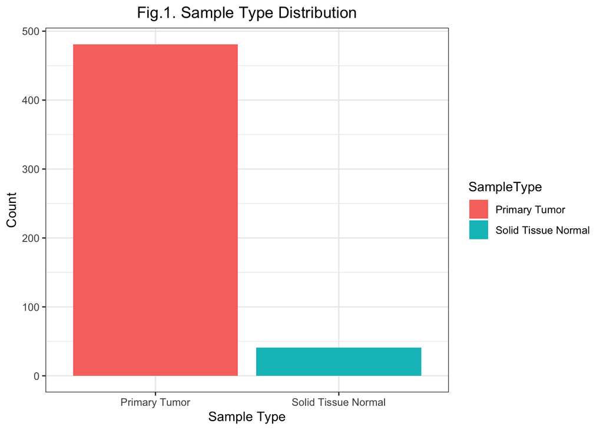

```r
names(sample_types_filtered) <- colnames(data.counts)
sample_info <- data.frame(Sample = names(sample_types_filtered), SampleType = sample_types_filtered)

# Plot the distribution
sample_info %>%
  group_by(SampleType) %>%
  summarize(Count = n()) %>%
  ggplot(aes(x = SampleType, y = Count, fill = SampleType)) +
  geom_bar(stat = "identity") +
  theme_bw() +
  labs(title = "Fig.1. Sample Type Distribution", x = "Sample Type", y = "Count") +
  theme(plot.title = element_text(hjust = 0.5))
```

#### 3.1.2 Preprocessing

We observed that most genes in the dataset have only one transcript, and a few genes (such as ENSG00000002586.20 and ENSG00000002586.20_PAR_Y) have two transcripts. Meanwhile, the ENSG00000002586.20_PAR_Y transcript has zero expression across all samples, providing no meaningful information for downstream analyses.

```r
data.counts %>%
  rownames_to_column(var = "Gene") %>%
  filter(Gene %in% c("ENSG00000002586.20", "ENSG00000002586.20_PAR_Y")) %>%
  dplyr::select(1:3)
```

```
##                       Gene TCGA.AA.3692.01A.01R.0905.07
## 1       ENSG00000002586.20                         8563
## 2 ENSG00000002586.20_PAR_Y                            0
##   TCGA.AA.3662.11A.01R.1723.07
## 1                         7980
## 2                            0
```

Therefore, removing these redundant transcripts can help simplify the dataset and reduce noise while retaining the biological significance of most of the data. After excluding 44 invalid transcripts, we also removed the transcript IDs from the gene names. In addition, considering that the upcoming analysis will involve DESeq2, DESeq2 recommends using safe characters in column names and row names to avoid potential problems. So, we replaced the ‘.’ character in the sample type name with a ‘-’ character.

```r
data.counts <- data.counts %>%
  rownames_to_column(var = "Gene") %>%
  filter(!grepl("_PAR", Gene)) %>%
  mutate(Gene = sub("\\..*", "", Gene))

sample_types_filtered <- gsub(" ", "_", sample_types_filtered)
```

#### 3.1.3 Quality control

From the figure below, we can see that the total reads of most samples are in the range of 2e+07 to 6e+07. The lower reads on the left side of the histogram indicate that that the sequencing depth of some samples may be low, which may mean that the gene expression in these samples is low. To improve the quality and reliability of downstream data analysis, we performed quality control, such as removing low-quality genes and samples.

```r
anyNA(data.counts)
```

```
## [1] FALSE
```

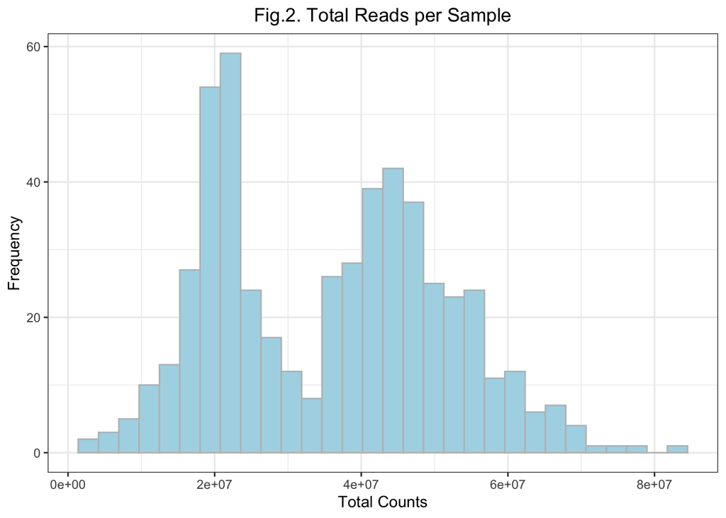

```r
data.counts <- data.counts %>%
  column_to_rownames(var = 'Gene')
sample_totals <- colSums(data.counts)
sample_totals_df <- data.frame(TotalCounts = sample_totals)

ggplot(sample_totals_df, aes(x = TotalCounts)) +
  geom_histogram(bins = 30, fill = "lightblue", color = "grey") +
  labs(title = "Fig.2. Total Reads per Sample", x = "Total Counts", y = "Frequency") +
  theme_bw() +
  theme(plot.title = element_text(hjust = 0.5))
```

```r
# 1. Sample must have 20M reads
idx <- colSums(data.counts) >= 20E6
data.counts.new <- data.counts[,idx]
sample_types_filtered <- sample_types_filtered[idx]
dim(data.counts.new) #60616   427
```

```
## [1] 60616   427
```

```r
# 2. Filtering out lowly expressed genes based on the log2(CPM)
data.counts.cpm <- cpm(data.counts.new, log = TRUE)
proportion_threshold <- 0.05
num_samples <- ncol(data.counts.new)
keep_genes <- rowSums(data.counts.cpm > 1) >= (proportion_threshold * num_samples)
data.counts.new = data.counts.new[keep_genes, ]
dim(data.counts.new)
```

```
## [1] 17129   427
```

```r
#rm(data.counts.cpm)
```

#### 3.1.4 Normalization

We used the DESeq2 package to perform the variance-stabilizing transformation (VST) on the count data.

```r
data_vst <- DESeq2::varianceStabilizingTransformation(as.matrix(data.counts.new))
data_vst <- data_vst - min(data_vst)
```

### 3.2 PCA

#### 3.2.1 PCA Computation

The results of the PCA are illustrated in Fig. 3 and Fig. 4, which depict the cumulative variance explained by the principal components and the dataset visualization based on PC1 and PC2, respectively.

As can be seen from the table below and Fig.3, the first two components only explain 26.92% of the cumulative variance, which is not very ideal. However, the first 20 principal components can explain 64% of the cumulative variance.

We can consider the reasons behind the low proportion of variance explained by the first two principal components. First of all, the dataset includes over 14,000 genes, which creates a very high-dimensional data space. However, we only have about 400 samples, which is much smaller than the number of genes. This imbanlance makes it harder to capture the variation, since the dimentionality reductions works better with more samples. Secondly, many genes in the dataset are highly correlated, which adds complexity to the data, resulting each components can explain less variance. Lastly, gene expression data naturally have complex patterns and interactions between genes, making it difficult for the first few principal components to capture a large proportion of the variance.

```r
# Perform the PCA
data.pca <- prcomp(t(data_vst))

# Summary of components
cumulative_variance <- summary(data.pca)$importance[3,]
cumulative_variance[1:30] # show the first 30 principle components
```

```
##     PC1     PC2     PC3     PC4     PC5     PC6     PC7     PC8     PC9    PC10
## 0.15656 0.26924 0.34751 0.40607 0.44082 0.46996 0.49214 0.51275 0.53010 0.54509
##    PC11    PC12    PC13    PC14    PC15    PC16    PC17    PC18    PC19    PC20
## 0.55734 0.56917 0.58096 0.59137 0.60083 0.60994 0.61829 0.62597 0.63357 0.64058
##    PC21    PC22    PC23    PC24    PC25    PC26    PC27    PC28    PC29    PC30
## 0.64721 0.65363 0.65967 0.66548 0.67113 0.67649 0.68172 0.68655 0.69113 0.69557
```

Beyond the 60th principal component, the curve of cumulative variance is smoother, indicating that the contributions of other components gradually decrease.

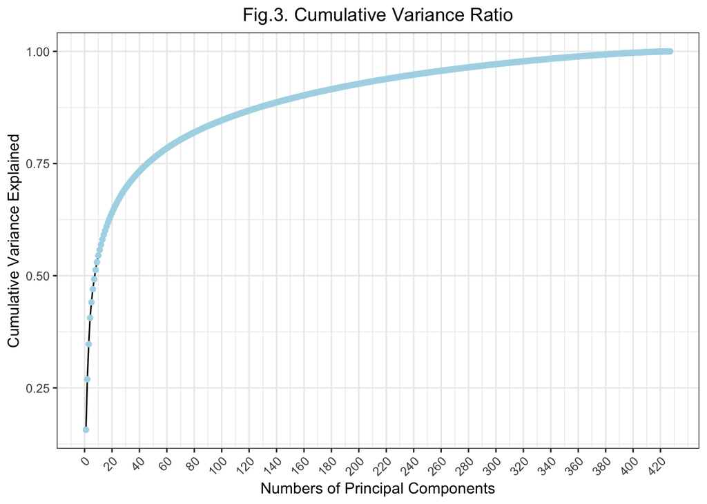

```r
# Plot the cumulative variance explained by the principle components
variance_df <- data.frame(PC = seq_along(cumulative_variance),CumulativeVariance = cumulative_variance)

ggplot(variance_df, aes(x = PC, y = CumulativeVariance)) +
  geom_line(color = "black") +
  geom_point(color = "lightblue") +
  theme_bw() +
  labs( title = "Fig.3. Cumulative Variance Ratio",
        x = "Numbers of Principal Components",
        y = "Cumulative Variance Explained"
        ) +
  scale_x_continuous(breaks = seq(0, length(cumulative_variance), by = 20)) +
  theme(plot.title = element_text(hjust = 0.5),
        axis.text.x = element_text(angle = 45, hjust = 1)
  )
```

In order to interpret our principal components, we hope to find which genes have the greatest impact on each PC. However, the number of original genes is too large, so we focus on the top ten important genes affecting PC1 and PC2.

```r
pc_loadings <- data.pca$rotation

pc_loadings <- pc_loadings %>%
  as_tibble(rownames = "gene")

genes_pc1 <- pc_loadings %>%
  dplyr::select(gene, PC1) %>%
  pivot_longer(matches("PC"), names_to = "PC", values_to = "loading") %>%
  group_by(PC) %>%
  arrange(desc(abs(loading))) %>%
  slice(1:10) %>%
  pull(gene) %>%
  unique()

print(genes_pc1)
```

```
##  [1] "ENSG00000133742" "ENSG00000132465" "ENSG00000211890" "ENSG00000133392"
##  [5] "ENSG00000211895" "ENSG00000016602" "ENSG00000211592" "ENSG00000196616"
##  [9] "ENSG00000175084" "ENSG00000204936"
```

```r
genes_pc2 <- pc_loadings %>%
  dplyr::select(gene, PC2) %>%
  pivot_longer(matches("PC"), names_to = "PC", values_to = "loading") %>%
  group_by(PC) %>%
  arrange(desc(abs(loading))) %>%
  slice(1:10) %>%
  pull(gene) %>%
  unique()

print(genes_pc2)
```

```
##  [1] "ENSG00000211890" "ENSG00000174992" "ENSG00000016490" "ENSG00000275395"
##  [5] "ENSG00000211895" "ENSG00000179914" "ENSG00000197273" "ENSG00000167434"
##  [9] "ENSG00000016602" "ENSG00000103375"
```

#### 3.2.2 Visualization on the First Two Principal Components

Then, we turn to visualize our samples on PC1 and PC2 space and distinguish the two classes. In this plot, there is a clear distinction between the primary tumor and solid tissue normal samples. The two classes are mostly separated by PC1, with primary tumors showing a more scattered distribution. And there are a few potential outliers in the lower right of the plot.

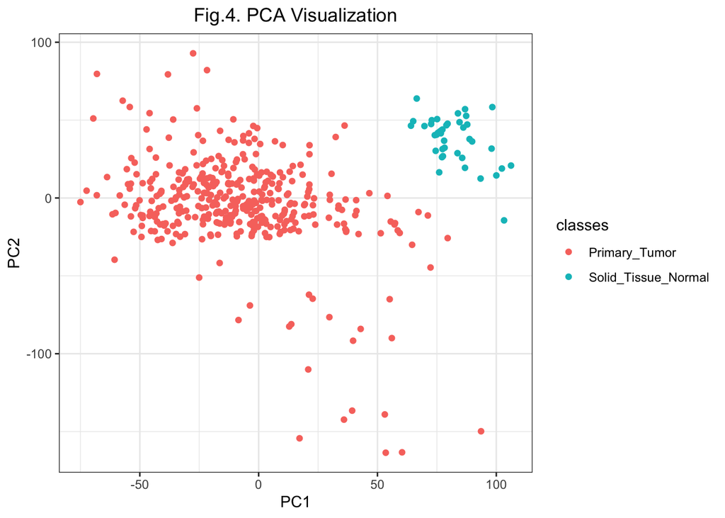

```r
classes <- sample_types_filtered %>% factor()

data.pca$x %>%
  ggplot(aes(PC1, PC2, col = classes)) +
  geom_point() +
  labs(title = "Fig.4. PCA Visualization", x = "PC1", y = "PC2") +
  theme_bw() +
  theme(plot.title = element_text(hjust = 0.5))
```

#### 3.2.3 Outlier Detection through PCA

Therefore, we tried to check the potential outliers found before and remove them, because the number of these outliers was very small, only 8 samples, and these outliers could have a great impact on the subsequent analysis, so we decided to remove them and perform the PCA analysis again to check the results of the before and after PCA.

```r
# Try to find outliers
pca_projection <- data.frame(Sample = rownames(data.pca$x),
                             PC1 = data.pca$x[, 1],
                             PC2 = data.pca$x[, 2])

outliers <- pca_projection %>%
  filter(PC2 < -100)

rownames(outliers)
```

```
## [1] "TCGA.A6.6781.01B.06R.A277.07" "TCGA.A6.3809.01B.04R.A277.07"
## [3] "TCGA.A6.3810.01B.04R.A277.07" "TCGA.A6.6650.01B.02R.A277.07"
## [5] "TCGA.A6.5659.01B.04R.A277.07" "TCGA.A6.2684.01C.08R.A277.07"
## [7] "TCGA.A6.2677.01B.02R.A277.07" "TCGA.A6.6780.01B.04R.A277.07"
```

```r
# Delete the outliers from the dataset
idx_2 <- which(colnames(data_vst) %in% rownames(outliers))

sample_types_filtered_new <- sample_types_filtered[-idx_2]
data_vst <- data_vst %>%
  as.data.frame() %>%
  dplyr::select(-rownames(outliers))
```

Now, we can see that the new samples based on PC1 and PC2 are more reasonably distributed, and PC1 seems to play a greater role in splitting the two classes.

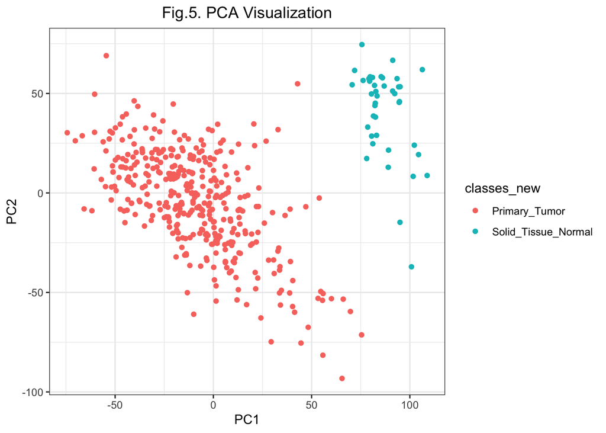

### 3.3 Differential Expression Analysis

#### 3.3.1 Calculation and filtering the DEGs

Here, we create a dataset object and specify the experimental conditions (such as “primary tumor” and “solid tissue normal”) though the DESeqDataSetFromMatrix function. Then we use the DESeq function to perform differential expression analysis and extract the analysis results.

```r
# Delete the outliers from the dataset
data.counts.new2 <- data.counts.new %>%
  as.data.frame() %>%
  dplyr::select(-rownames(outliers))
dim(data.counts.new2) #17129   419
```

```
## [1] 17129   419
```

```r
# Read in RNA-Seq count data and design
suppressMessages({
dds <- DESeq2::DESeqDataSetFromMatrix(
  countData = as.matrix(data.counts.new2),
  colData = data.frame(condition = factor(classes_new, levels = c("Primary_Tumor","Solid_Tissue_Normal"))),
  design = ~ condition)

dds <- DESeq2::DESeq(dds)
res <- DESeq2::results(dds)
as.data.frame(res)[1:10,]
res <- as.data.frame(res)
})
```

Then, we screened out differentially expressed genes based on log2FoldChange and padj, and the thresholds of these two parameters were selected based on the Maurya paper [2]. A total of 2803 genes were screened, including 1389 up-regulated genes and 1414 down-regulated genes.

```r
res0.05 <- res %>%
  filter(padj< 0.01 & abs(log2FoldChange)>1.5) %>%
  arrange(padj)

dim(res0.05)
```

```
## [1] 2803    6
```

```r
DEGs_up_genes <- res0.05[res0.05$log2FoldChange>0,] %>%
  rownames_to_column("Gene") %>%
  dplyr::select("Gene") %>%
  pull("Gene")

head(res0.05[res0.05$log2FoldChange>0,])
```

```
##                  baseMean log2FoldChange      lfcSE     stat        pvalue
## ENSG00000142959  411.9235       6.213373 0.22397130 27.74182 2.186804e-169
## ENSG00000169764 5177.8738       2.155769 0.08118268 26.55455 2.275595e-155
## ENSG00000040199 1087.3234       2.728071 0.11210256 24.33549 8.257614e-131
## ENSG00000215193 3256.2963       1.880435 0.07773449 24.19048 2.801792e-129
## ENSG00000136044 2861.3565       1.950798 0.08069808 24.17403 4.173950e-129
## ENSG00000162461  103.5915       4.174469 0.17745435 23.52419 2.307285e-122
##                          padj
## ENSG00000142959 3.405251e-166
## ENSG00000169764 2.998360e-152
## ENSG00000040199 7.072233e-128
## ENSG00000215193 2.181449e-126
## ENSG00000136044 3.108504e-126
## ENSG00000162461 1.411482e-119
```

```r
DEGs_down_genes <- res0.05[res0.05$log2FoldChange<0,] %>%
  rownames_to_column("Gene") %>%
  dplyr::select("Gene") %>%
  pull("Gene")

head(res0.05[res0.05$log2FoldChange<0,])
```

```
##                  baseMean log2FoldChange     lfcSE      stat        pvalue
## ENSG00000062038 3806.2553      -6.008578 0.1516020 -39.63388  0.000000e+00
## ENSG00000167767 1612.6073      -6.784756 0.1823747 -37.20229 6.266536e-303
## ENSG00000175832 4161.4770      -5.298397 0.1471336 -36.01079 5.670701e-284
## ENSG00000164283  284.3680      -5.797140 0.1863152 -31.11469 1.524516e-212
## ENSG00000164379 2545.3838      -6.193840 0.2004227 -30.90389 1.058974e-209
## ENSG00000159263  379.3355      -7.997299 0.2673723 -29.91073 1.427341e-196
##                          padj
## ENSG00000062038  0.000000e+00
## ENSG00000167767 5.366975e-299
## ENSG00000175832 3.237781e-280
## ENSG00000164283 6.528360e-209
## ENSG00000164379 3.627834e-206
## ENSG00000159263 4.074820e-193
```

```r
#The number of upregulated genes
print(length(DEGs_up_genes))
```

```
## [1] 1389
```

```r
#The number of downregulated genes
print(length(DEGs_down_genes))
```

```
## [1] 1414
```

#### 3.3.2 Volcano plot

Finally, the results can be visualized to easily observe patterns and gain some potential understanding.

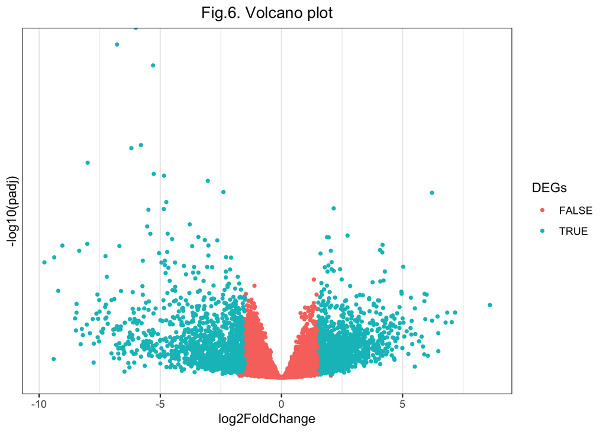

```r
res %>%
  filter(baseMean>0 & log2FoldChange > -10 & !is.na(padj)) %>%
  mutate(DEGs = ifelse(padj< 0.01 & abs(log2FoldChange)>1.5 , "TRUE", "FALSE")) %>%
  ggplot(aes(x = log2FoldChange, y = 1/padj, color = DEGs )) +
  geom_point(size = 1) +
  scale_y_log10() +
  labs(x = "log2FoldChange", y = "-log10(padj)", title = "Fig.6. Volcano plot") +
  theme_bw() +
  theme(plot.title = element_text(hjust = 0.5))
```

### 3.4 Modelling

#### 3.4.1 Train-test split

The dataset was divided into training (70%) and test (30%) sets following normalization. The larger portion will be used to train the model and the other to evaluate the model’s performance on unseen data. A stratified splitting approach was used to maintain class proportions, ensuring that both sets are representative of the full dataset, and doesn’t contain a skewed proportion of Tumor vs Normal samples.

```r
# Perform train-test split on VST-normalized data
set.seed(42)  # For reproducibility
vst_matrix <- data_vst
table(classes_new)
```

```
## classes_new
##       Primary_Tumor Solid_Tissue_Normal
##                 378                  41
```

```r
train_idx <- createDataPartition(classes_new, p = 0.7, list = FALSE)

# Subset normalized data and labels
train_features <- t(vst_matrix[, train_idx])  # Transpose for modeling
test_features <- t(vst_matrix[, -train_idx])  # Transpose for modeling
train_labels <- as.factor(sample_types_filtered_new[train_idx])
test_labels <- as.factor(sample_types_filtered_new[-train_idx])
```

#### 3.4.2 Data Balancing

Since dataset exhibits a significant class imbalance, with far more Tumor samples (378) than Normal samples (41), we chose to apply weighting in order to address the imbalance.

```r
# Calculate class weights
class_counts <- table(train_labels)
class_weights <- max(class_counts) / class_counts
print(class_weights)
```

```
## train_labels
##       Primary_Tumor Solid_Tissue_Normal
##            1.000000            9.137931
```

Weighting modifies the importance of each class by assigning weights inversely proportional to their frequencies. This way, predictions favor neither the majority nor the minority class.

#### 3.4.3 Weighted k-Nearest Neighbors (kNN)

##### Training the Model

```r
set.seed(42)
weighted_knn <- train(
  x = train_features,
  y = train_labels,
  method = "knn",
  tuneGrid = expand.grid(k = seq(3, 15, by = 2)),  # Odd k values
  trControl = trainControl(method = "cv", number = 10, classProbs = TRUE),
  weights = as.numeric(class_weights[train_labels])  # Apply class weights
)

# Display the best k value
cat("Best k value:", weighted_knn$bestTune$k, "\n")
```

```
## Best k value: 11
```

The kNN model was trained using weighted class frequencies to address imbalance. The optimal value of k, 11 was determined using 10-fold cross-validation.

##### Making Predictions

```r
# Make predictions
predicted_labels <- predict(weighted_knn, newdata = test_features)
```

##### Evaluating the model

```r
# Confusion matrix
confusion <- table(Real = test_labels, Predicted = predicted_labels)
print(confusion)
```

```
##                      Predicted
## Real                  Primary_Tumor Solid_Tissue_Normal
##   Primary_Tumor                 113                   0
##   Solid_Tissue_Normal             0                  12
```

```r
# Accuracy and error rate
accuracy <- sum(diag(confusion)) / sum(confusion)
cat("Accuracy:", accuracy, "\n")
```

```
## Accuracy: 1
```

```r
error <- 1 - accuracy
cat("Error rate:", error, "\n")
```

```
## Error rate: 0
```

The model has an accuracy of 100%. It may indicate overfitting or Data leakeage.

#### 3.4.4 Random Forest

The same random split as used in the k-NN model was applied to maintain consistency.

##### Training the Model

```r
# Train a random forest model
rf_model <- randomForest(
  x = train_features,
  y = train_labels,
  ntree = 500,              # Number of trees
  mtry = sqrt(ncol(train_features)),  # Features tried at each split
  classwt = as.numeric(class_weights),  # Apply class weights
  importance = TRUE         # Enable feature importance calculation
)

# Print model summary
print(rf_model)
```

```
##
## Call:
##  randomForest(x = train_features, y = train_labels, ntree = 500,      mtry = sqrt(ncol(train_features)), classwt = as.numeric(class_weights),      importance = TRUE)
##                Type of random forest: classification
##                      Number of trees: 500
## No. of variables tried at each split: 131
##
##         OOB estimate of  error rate: 0.68%
## Confusion matrix:
##                     Primary_Tumor Solid_Tissue_Normal class.error
## Primary_Tumor                 265                   0  0.00000000
## Solid_Tissue_Normal             2                  27  0.06896552
```

A Random Forest model was trained using 500 trees and weighted class frequencies to address imbalance. Feature importance was calculated to identify key contributors to classification.

##### Making Predictions

```r
# Make predictions
rf_predictions <- predict(rf_model, newdata = test_features)
```

##### Evaluating the model

```r
# Confusion matrix
confusion <- table(Real = test_labels, Predicted = rf_predictions)
print(confusion)
```

```
##                      Predicted
## Real                  Primary_Tumor Solid_Tissue_Normal
##   Primary_Tumor                 113                   0
##   Solid_Tissue_Normal             0                  12
```

```r
# Accuracy and error rate
accuracy <- sum(diag(confusion)) / sum(confusion)
cat("Accuracy:", accuracy, "\n")
```

```
## Accuracy: 1
```

```r
error <- 1 - accuracy
cat("Error rate:", error, "\n")
```

```
## Error rate: 0
```

The confusion matrix, accuracy, and error rate were calculated to evaluate the performance of the Random Forest model. The model has an accuracy of 100%. This could indicate several possibilities. It might be the model is showing excellent performance, with the data set being naturally well-separated. With only 29 samples in the Normal class, the model might perform perfectly due to limited diversity in the minority class. It could also be a result of overfitting, or data leakage. To confirm whether the high accuracy reflects true model performance or something is wrong, we will perform some further testing :

##### Checking the Split

```r
# Check class distribution in training and test sets
cat("Training set class distribution:\n")
```

```
## Training set class distribution:
```

```r
print(table(train_labels))
```

```
## train_labels
##       Primary_Tumor Solid_Tissue_Normal
##                 265                  29
```

```r
cat("Test set class distribution:\n")
```

```
## Test set class distribution:
```

```r
print(table(test_labels))
```

```
## test_labels
##       Primary_Tumor Solid_Tissue_Normal
##                 113                  12
```

The splits seem to be even.

##### Test for Data Leakage

```r
any(duplicated(rbind(train_features, test_features)))
```

```
## [1] FALSE
```

##### Evaluate with Cross-Validation

```r
set.seed(42)
rf_cv <- train(
  x = train_features,
  y = train_labels,
  method = "rf",
  trControl = trainControl(method = "cv", number = 10),
  tuneGrid = expand.grid(mtry = sqrt(ncol(train_features)))
)
print(rf_cv)
```

```
## Random Forest
##
##   294 samples
## 17129 predictors
##     2 classes: 'Primary_Tumor', 'Solid_Tissue_Normal'
##
## No pre-processing
## Resampling: Cross-Validated (10 fold)
## Summary of sample sizes: 265, 265, 265, 265, 264, 265, ...
## Resampling results:
##
##   Accuracy   Kappa
##   0.9965517  0.9781955
##
## Tuning parameter 'mtry' was held constant at a value of 130.8778
```

The high accuracy and kappa values indicate that the Random Forest model generalizes well across different subsets of the data, and there is no significant sign of overfitting. It seems the model is highly reliable for separating Primary Tumor and Solid Tissue Normal samples. The consistent results across folds highlight the model’s reliability and its ability to handle the significant class imbalance effectively.

##### Feature Importance

Feature importance is a metric used to identify the most influential features in a predictive model. In this analysis, it quantifies each feature’s contribution to reducing classification uncertainty, measured by the Mean Decrease Gini. In other words, these genes makes the model able to separate the tumor and normal samples. Features with higher importance scores are key drivers of the model’s accuracy and therefore may provide insights into the underlying biological processes affected in cancer cells.

```r
# Extract feature importance
importance <- importance(rf_model)
feature_importance <- data.frame(
  Feature = rownames(importance),
  Importance = importance[, "MeanDecreaseGini"]
)

# Top 10 features
top_features <- feature_importance[order(-feature_importance$Importance), ][1:10, ]
print(top_features)
```

```
##                         Feature Importance
## ENSG00000141668 ENSG00000141668  1.0264231
## ENSG00000065325 ENSG00000065325  0.9303595
## ENSG00000175832 ENSG00000175832  0.5300846
## ENSG00000164283 ENSG00000164283  0.5273260
## ENSG00000101255 ENSG00000101255  0.5261406
## ENSG00000168079 ENSG00000168079  0.5216891
## ENSG00000167767 ENSG00000167767  0.5206890
## ENSG00000182271 ENSG00000182271  0.5156067
## ENSG00000108381 ENSG00000108381  0.5134389
## ENSG00000158828 ENSG00000158828  0.5049458
```

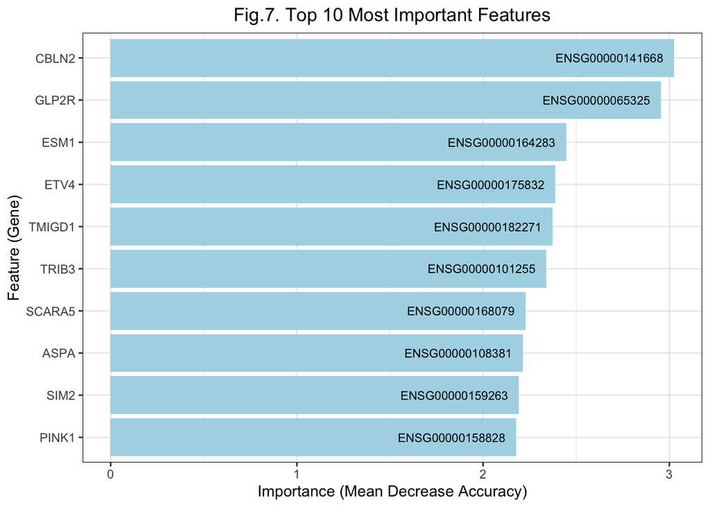

```r
gene_names <- read.delim("genenames.org.txt", header = TRUE) %>%
  na.omit()

genetable <- rf_model %>%
  importance() %>%
  as.data.frame() %>%
  rownames_to_column(var = "Genes") %>%
  mutate(Genes = sub("\\..*", "", Genes)) %>%
  left_join(gene_names, by = c("Genes" = "Ensembl.gene.ID")) %>%
  na.omit() %>%
  top_n(10, MeanDecreaseAccuracy) %>%
  arrange(desc(MeanDecreaseAccuracy)) %>%
  dplyr::select("Genes", "MeanDecreaseAccuracy", "Symbol")

# Plot feature importance
ggplot(genetable, aes(x = reorder(Symbol, MeanDecreaseAccuracy), y = MeanDecreaseAccuracy)) +
  geom_bar(stat = "identity", fill = "lightblue") +
  coord_flip() +
geom_text(aes(label = Genes), size =3, hjust = 1.1) +
  theme_bw() +
  labs(
    title = "Fig.7. Top 10 Most Important Features",
    x = "Feature (Gene)",
    y = "Importance (Mean Decrease Accuracy)"
  )+
theme(plot.title = element_text(hjust = 0.5))
```

### 3.5 Biological Relevance

Gene Ontology (GO) enrichment analysis highlighted key biological processes associated with the top genes that distinguished tumor and normal samples. From the differential expression analysis, we identified significantly up-regulated and down-regulated genes, as well as significant genes identified by random forest models. GO enrichment analysis allowed us to link these genes to relevant biological processes.

#### 3.5.1 GO Analysis of Up/Downregulated Genes

The results shows that the genes upregulated were enriched for gene ontology categories related to immunity and muscle activity, whereas the downregulated genes showed enrichment for gene ontology categories implicated in extracellular matrix organization and Wnt signaling pathway.

```r
go_DEGs_up <- enrichGO(gene = DEGs_up_genes, OrgDb = org.Hs.eg.db, keyType = "ENSEMBL", ont = "BP")
go_DEGs_up_df <- as.data.frame(go_DEGs_up)

go_DEGs_up_df[1:10,2:7]
```

```
##                                                                                                                          Description
## GO:0002377                                                                                                 immunoglobulin production
## GO:0002440                                                                       production of molecular mediator of immune response
## GO:0016064                                                                                   immunoglobulin mediated immune response
## GO:0019724                                                                                                  B cell mediated immunity
## GO:0003012                                                                                                     muscle system process
## GO:0006936                                                                                                        muscle contraction
## GO:0002460 adaptive immune response based on somatic recombination of immune receptors built from immunoglobulin superfamily domains
## GO:0006939                                                                                                 smooth muscle contraction
## GO:0043270                                                                           positive regulation of monoatomic ion transport
## GO:0035725                                                                                        sodium ion transmembrane transport
##            GeneRatio   BgRatio       pvalue     p.adjust       qvalue
## GO:0002377   65/1191 209/21261 3.840160e-31 2.018004e-27 1.686841e-27
## GO:0002440   76/1191 402/21261 4.217445e-21 1.108134e-17 9.262840e-18
## GO:0016064   54/1191 234/21261 2.297217e-19 4.023958e-16 3.363609e-16
## GO:0019724   54/1191 244/21261 1.718380e-18 2.257522e-15 1.887053e-15
## GO:0003012   79/1191 477/21261 2.757972e-18 2.898628e-15 2.422951e-15
## GO:0006936   68/1191 373/21261 3.967377e-18 3.474761e-15 2.904538e-15
## GO:0002460   69/1191 495/21261 2.282968e-12 1.713857e-09 1.432606e-09
## GO:0006939   29/1191 113/21261 2.892282e-12 1.899868e-09 1.588091e-09
## GO:0043270   42/1191 231/21261 1.157874e-11 6.760699e-09 5.651239e-09
## GO:0035725   35/1191 187/21261 2.626307e-10 1.380124e-07 1.153640e-07
```

```r
go_DEGs_down <- enrichGO(gene = DEGs_down_genes, OrgDb = org.Hs.eg.db, keyType = "ENSEMBL", ont = "BP", pvalueCutoff = 0.05)
go_DEGs_down_df <- as.data.frame(go_DEGs_down)

go_DEGs_down_df[1:10,2:7]
```

```
##                                              Description GeneRatio   BgRatio
## GO:0030198             extracellular matrix organization    51/921 376/21261
## GO:0043062          extracellular structure organization    51/921 377/21261
## GO:0008544                         epidermis development    55/921 429/21261
## GO:0045229 external encapsulating structure organization    51/921 379/21261
## GO:2000027      regulation of animal organ morphogenesis    29/921 139/21261
## GO:0043588                              skin development    48/921 350/21261
## GO:0016055                         Wnt signaling pathway    54/921 485/21261
## GO:0198738                    cell-cell signaling by wnt    54/921 487/21261
## GO:0019730                antimicrobial humoral response    28/921 164/21261
## GO:0051216                         cartilage development    33/921 222/21261
##                  pvalue     p.adjust       qvalue
## GO:0030198 4.598241e-13 7.720497e-10 6.532176e-10
## GO:0043062 5.101909e-13 7.720497e-10 6.532176e-10
## GO:0008544 5.705932e-13 7.720497e-10 6.532176e-10
## GO:0045229 6.273002e-13 7.720497e-10 6.532176e-10
## GO:2000027 1.361762e-12 1.236567e-09 1.046237e-09
## GO:0043588 1.507089e-12 1.236567e-09 1.046237e-09
## GO:0016055 2.190549e-10 1.540582e-07 1.303459e-07
## GO:0198738 2.551272e-10 1.569989e-07 1.328340e-07
## GO:0019730 4.759065e-10 2.603209e-07 2.202529e-07
## GO:0051216 5.885511e-10 2.835599e-07 2.399150e-07
```

#### 3.5.2 GO Analysis of genes seleted from rf model

```r
selectted_gene <- rf_model %>%
  importance() %>%
  as.data.frame() %>%
  rownames_to_column(var = "Genes") %>%
  mutate(Genes = sub("\\..*", "", Genes)) %>%
  top_n(1000, MeanDecreaseAccuracy) %>%
  arrange(desc(MeanDecreaseAccuracy)) %>%
  dplyr::select("Genes") %>%
  pull()

go_selectted_gene <- enrichGO(gene = selectted_gene, OrgDb = org.Hs.eg.db, keyType = "ENSEMBL", ont = "BP")

go_selectted_gene_df <- as.data.frame(go_selectted_gene)

print(go_selectted_gene_df[1:10,2:7])
```

```
##                                                   Description GeneRatio
## GO:0051656            establishment of organelle localization 425/13649
## GO:0016055                              Wnt signaling pathway 411/13649
## GO:0198738                         cell-cell signaling by wnt 412/13649
## GO:0034470                                   ncRNA processing 409/13649
## GO:0007163      establishment or maintenance of cell polarity 217/13649
## GO:0006260                                    DNA replication 263/13649
## GO:0006261                      DNA-templated DNA replication 155/13649
## GO:0006302                         double-strand break repair 281/13649
## GO:0072594 establishment of protein localization to organelle 409/13649
## GO:0001701                     in utero embryonic development 362/13649
##              BgRatio       pvalue     p.adjust       qvalue
## GO:0051656 495/21261 8.230039e-28 5.512480e-24 3.259095e-24
## GO:0016055 485/21261 1.861471e-24 6.234068e-21 3.685713e-21
## GO:0198738 487/21261 3.313131e-24 7.397116e-21 4.373332e-21
## GO:0034470 490/21261 1.055668e-21 1.767716e-18 1.045111e-18
## GO:0007163 239/21261 1.455800e-21 1.950190e-18 1.152994e-18
## GO:0006260 298/21261 2.138654e-21 2.387450e-18 1.411511e-18
## GO:0006261 163/21261 3.476593e-21 3.326603e-18 1.966758e-18
## GO:0006302 322/21261 4.427703e-21 3.707094e-18 2.191713e-18
## GO:0072594 494/21261 2.266762e-20 1.686975e-17 9.973753e-18
## GO:0001701 431/21261 2.727756e-20 1.827051e-17 1.080191e-17
```

## 4. Discussion

### 4.1 Conclusion

This paper completes a series of analysis pipelines, starting from raw data, preprocessing, filtering genes, removing outliers identified by PCA, differentially expressed genes, creating classification models using machine learning methods, and GO enrichment analysis. Our supervised model performed very well, with no signs of overfitting or data leakage. From the interpretation of GO enrichment analysis of gene sets based on differential expression analysis and RF model, we obtained common biological insights, that is, the results involve key pathways and processes in tumor biology, such as cell signaling (especially Wnt pathway), extracellular matrix organization, which play an important role in tumorigenesis.

### 4.2 Further study

Future research directions can explore other data preprocessing methods, such as correlation analysis, and LASSO filtering to further reduce the dimension before building the model. At the same time, advanced machine learning methods such as deep learning can also be used to process high-dimensional, low-sample biological data sets. For differentially expressed genes and genes screened from the RF model, we can find common genes from both methods to narrow the range of genes of interest. In terms of research depth, we now use GO enrichment analysis to gain insight into the functional groups of important genes, and then pathway maps can be used to help determine how these genes affect biological systems. In addition, experimental validation of selected genes and integration of multi-omics data will help to gain a deeper understanding of biological mechanisms and seek practical applications of these findings.

## References

1. Colaprico, A. et al. TCGAbiolinks: an R/Bioconductor package for integrative analysis of TCGA data. Nucleic Acids Res. 44(8), e71 (2016).
2. Maurya, N.S., Kushwaha, S., Chawade, A. et al. Transcriptome profiling by combined machine learning and statistical R analysis identifies TMEM236 as a potential novel diagnostic biomarker for colorectal cancer. Sci Rep 11, 14304 (2021).
3. Ringnér, M. What is principal component analysis?. Nat Biotechnol 26, 303–304 (2008).
4. Rosati, Diletta et al. “Differential gene expression analysis pipelines and bioinformatic tools for the identification of specific biomarkers: A review.” Computational and structural biotechnology journal vol. 23 1154-1168. 1 Mar. 2024.